# Data Quality Control Report: TinyEHR for the MDLA Critical-Care Mortality Protocol

Is this dataset fit to reproduce Patel and Beedala (medRxiv 2026)?

Author

Prepared with the data-quality-evaluation and tinyehr-context skills

Published

2026-10-12

# Verdict

**Fit with caveats for a protocol-aware data-quality demonstration (Stages A to D). Not fit for reproducing the MDLA model, fairness or calibration estimates.**

The analytical cohort has **72 patients** (72.0% of the 100 TinyEHR patients, against 50,827 ICU stays in the published study) and **<10 in-hospital deaths**. The perfect-record score over the 15 critical data elements is **81.9%** (95% CI 71.5 to 89.1) against a 97% bar; it rises to **95.8%** (CI 88.5 to 98.6) once race, the single largest defect, is set aside. Cohort construction, the first-24-hour feature inventory, the data-quality checks and the missingness audit can all be executed and are informative. The prediction, 5-fold cross-validation, subgroup fairness (n >= 30) and group calibration (n >= 50) stages cannot be carried out with any validity.

[output not shown]

# 1 Intended use and data customer

**Decision supported.** Decide whether TinyEHR can be used to reproduce the MDLA study workflow (protocol `protocol/MDLA_MIMIC_IV_Reproduction_Protocol.md`) and which parts of the protocol are or are not reproducible. The protocol itself (section 25) frames the preferred question as: *can an agent correctly determine whether this dataset is fit to reproduce the study, identify the data-quality risks, execute the checks and explain what is and is not reproducible?*

**Data customer.** The researcher or conference audience who will rely on the demonstration (RSS data quality conference, Edinburgh, 22 October 2026). Their definition of “error” is taken from the protocol sections 5, 11 and 22.

**Critical data elements (15).** The perfect-record score is computed over exactly these.

| Group | Critical data element | Operational definition of an error |
| --- | --- | --- |
| Index | Age at ICU admission | Not derivable, <18 or >120 years |
| Index | Sex | Not F or M |
| Index | Race | Missing, UNKNOWN, UNABLE TO OBTAIN or PATIENT DECLINED |
| Index | In-hospital mortality | Flag disagrees with deathtime or discharge location DIED |
| Index | ICU timestamps | Outtime <= intime, or intime outside the admission interval |
| Physiology | Heart rate, SBP, MAP, respiratory rate, SpO2, temperature, GCS total | No valid observation (present, unit-correct, plausible) in the first 24 h |
| Physiology | Creatinine | No valid observation in the first 24 h |
| Composite | Urine output (24 h) | No valid output record in the first 24 h |
| Composite | Elixhauser comorbidity count | No diagnosis codes for the index admission |

**Acceptance standard.** Redman’s loosest bar of 97% perfect records. A research reproduction would normally ask for more, an exploratory demonstration for less; the bar is stated so the reader can move it.

# 2 Data pedigree

Pedigree answers come from the `tinyehr-context` skill (section 1 of `Database_Context.md`); anything the documentation leaves open is listed as an unknown and carried into the limitations.

[output not shown]

`anchor_age` is capped at **91** in the data (maximum observed in the cohort is 91 years; no value of 300 occurs), which resolves open question Q7 in favour of the `patients` table documentation.

# 3 Stage A: cohort construction

## 3.1 Attrition

Cohort attrition

Protocol order, section 22 Stage A; unit shown as patients, admissions and ICU stays

| Step | Criterion | Patients | Admissions | ICU stays | Patients lost | % of patients remaining |
| --- | --- | --- | --- | --- | --- | --- |
| 0 | All TinyEHR patients (admissions / ICU stays as available) | 100 | 275 | 140 | 0 | 100 |
| 1 | Age >= 18 years | 100 | 275 | 140 | 0 | 100 |
| 2 | First hospital admission of the patient | 100 | 100 | 80 | 0 | 100 |
| 3 | First ICU stay in that admission (admission must have an ICU stay) | 74 | 74 | 74 | 26 | 74 |
| 4 | ICU length of stay >= 4 hours | 72 | 72 | 72 | 2 | 72 |
| 5 | In-hospital mortality outcome available | 72 | 72 | 72 | 0 | 72 |

Admissions and ICU stays after step 2 are those of each patient's first hospital admission. ICU stays in earlier rows are all ICU stays belonging to the admissions that remain.

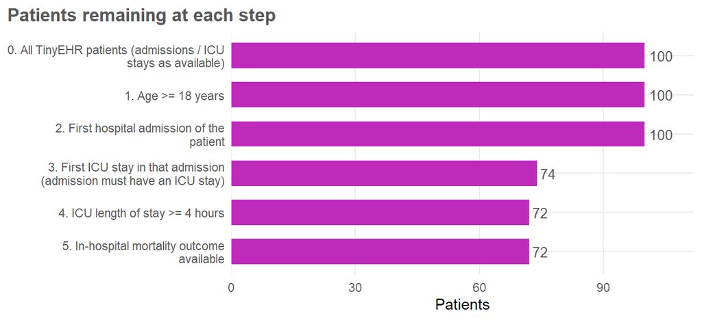

**The dominant loss is step 3, not the protocol criteria that look strict.** Of 100 patients, 26 lose their place because their *first* hospital admission has no ICU stay: the protocol hierarchy (patient, first admission, first ICU stay in that admission) discards a patient whose ICU stay occurs in a later admission. This is a faithful application of the protocol rather than an error, but it is a definition choice that moves the cohort, and the next section shows by how much.

## 3.2 Sensitivity to the cohort definition (tiered definitions)

Headline cohort under four definitions

Tate's tiered-definition sensitivity; Tier 1 is the protocol

| Cohort definition | ICU stays | Patients | Deaths | In-hospital mortality |
| --- | --- | --- | --- | --- |
| 1 Strict protocol (first admission, first ICU stay) | 72 | 72 | <10 | <10 deaths |
| 2 First ICU stay of the patient, any admission | 98 | 98 | 10 | 10.2% |
| 3 First ICU stay of every admission | 126 | 98 | 14 | 11.1% |
| 4 All ICU stays (no uniqueness rule) | 137 | 99 | 18 | 13.1% |

Relaxing the “first admission” rule enlarges the cohort by more than a third and moves the death count from fewer than 10 to 10 or more, because deaths are more frequent among the patients added. **The answer to “how many deaths are available” depends on a definition the data cannot settle.** Tier 1 is used throughout because it is the protocol.

## 3.3 Baseline characteristics

| **Characteristic** | **Index cohort**, N = 72<sup>1</sup> |
| --- | --- |
| Age at ICU admission (years) | 60.0 (48.0, 70.0) |
| Age stratum |  |
| 18-44 | 13 (18%) |
| 45-64 | 32 (44%) |
| 65-74 | 12 (17%) |
| >=75 | 15 (21%) |
| Sex |  |
| Female | 28 (39%) |
| Male | 44 (61%) |
| Race/ethnicity (harmonised) |  |
| White | 52 (72%) |
| Black | <10 |
| Hispanic | <10 |
| Asian | 0 (0%) |
| Other | 13 (18%) |
| Insurance |  |
| Medicare | (suppressed) |
| Medicaid | <10 |
| Other/Unknown | 42 (58%) |
| ICU type (harmonised) |  |
| MICU | 13 (18%) |
| SICU | 17 (24%) |
| CCU | <10 |
| NICU | <10 |
| TSICU | <10 |
| Other | 27 (38%) |
| ICU length of stay (days) | 2.0 (1.2, 4.9) |
| Elixhauser comorbidity count | 3.0 (2.0, 5.0) |
| In-hospital mortality |  |
| Survived | (suppressed) |
| Died in hospital | <10 |

<sup>1</sup> Median (Q1, Q3) or n (%). Cells with 1-9 patients are shown as <10; where a single level of a variable is hidden, the smallest remaining level is also hidden (complementary suppression). Race, insurance and ICU type are analyst harmonisations of the raw TinyEHR fields.

Two harmonisation findings matter for the MDLA subgroup analyses. First, **no Asian patient** is present. Second, the protocol’s six ICU types (MICU, SICU, CCU, NICU, TSICU, Other) cannot absorb TinyEHR’s care units: the cardiac-vascular ICU (CVICU) and the medical/surgical ICU have no protocol category, and the neuro step-down unit is not an ICU in the usual sense but is listed in `icustays`. The residual group “Other” is therefore the **largest** ICU type, which defeats its purpose as a small catch-all.

# 4 Stage B: first-24-hour feature inventory

## 4.1 Variable-to-database mapping

The protocol gives no item identifiers (its section 27 says to take them from the authors’ code). The mapping below is therefore an analyst mapping, checked against `d_items` and `d_labitems`: all mapped identifiers exist in the dictionaries. Seven vital-sign domains, 22 laboratory concepts, urine output and the Elixhauser count give **31 measurable concepts**; the protocol counts 44 candidate features.

Variable-to-database mapping

Limits other than creatinine and pH are analyst assumptions

| Group | Concept | Source table | Item IDs mapped | Plausibility limit | Limit origin | Used in final 43 |
| --- | --- | --- | --- | --- | --- | --- |
| Vital | gcs_total | chartevents | 220739, 223900, 223901 | 3 to 15 | GCS total range (derived) | Yes |
| Vital | heart_rate | chartevents | 220045 | 0 to 300 | assumed | Yes |
| Vital | map | chartevents | 220052, 220181 | 10 to 250 | assumed | Yes |
| Vital | resp_rate | chartevents | 220210, 224690 | 0 to 80 | assumed | Yes |
| Vital | sbp | chartevents | 220050, 220179 | 20 to 300 | assumed | Yes |
| Vital | spo2 | chartevents | 220277 | 0 to 100 | assumed | Yes |
| Vital | temperature | chartevents | 223761, 223762 | 25 to 45 | assumed | Yes |
| Laboratory | albumin | labevents | 50862, 52022, 53085 | 0.5 to 7 | assumed | Yes |
| Laboratory | alt | labevents | 50861, 53084 | 1 to 10000 | assumed | Yes |
| Laboratory | ast | labevents | 50878, 53088 | 1 to 10000 | assumed | Yes |
| Laboratory | bicarbonate | labevents | 50882 | 2 to 60 | assumed | Yes |
| Laboratory | bilirubin | labevents | 50885, 53089 | 0.1 to 70 | assumed | Yes |
| Laboratory | bun | labevents | 51006, 52647 | 1 to 300 | assumed | Yes |
| Laboratory | chloride | labevents | 50806, 50902, 52434, 52535 | 50 to 150 | assumed | Yes |
| Laboratory | creatinine | labevents | 50912, 52024, 52546 | 0.1 to 30 | protocol | Yes |
| Laboratory | glucose | labevents | 50809, 50931, 52027, 52569 | 10 to 2000 | assumed | Yes |
| Laboratory | hematocrit | labevents | 50810, 51221 | 5 to 70 | assumed | Yes |
| Laboratory | hemoglobin | labevents | 50811, 51222 | 1 to 25 | assumed | Yes |
| Laboratory | inr | labevents | 51237 | 0.5 to 20 | assumed | Yes |
| Laboratory | lactate | labevents | 50813, 52442, 53154 | 0.1 to 30 | assumed | Yes |
| Laboratory | paco2 | labevents | 50818 | 5 to 200 | assumed | Yes |
| Laboratory | pao2 | labevents | 50821 | 10 to 800 | assumed | Yes |
| Laboratory | ph | labevents | 50820 | 6.5 to 8 | protocol | Yes |
| Laboratory | platelets | labevents | 51265 | 1 to 2000 | assumed | Yes |
| Laboratory | potassium | labevents | 50822, 50971, 52452, 52610 | 1.5 to 10 | assumed | Yes |
| Laboratory | ptt | labevents | 51275, 52923 | 10 to 300 | assumed | Yes |
| Laboratory | sodium | labevents | 50824, 50983, 52455, 52623 | 90 to 190 | assumed | Yes |
| Laboratory | troponin | chartevents + labevents | 51002, 51003, 52642, 227429 | 0 to 1000 | assumed | No (troponin) |
| Laboratory | wbc | labevents | 51300, 51301 | 0.1 to 500 | assumed | Yes |
| Composite | elixhauser_count | diagnoses_icd | ICD-9/10 codes (Quan Elixhauser, 31 categories) | n/a | n/a | Yes |
| Composite | urine_output | outputevents | 226557, 226558, 226559, 226560, 226561, 226563, 226564, 226565, 226567, 226584 | 0 to 5000 | assumed (per record) | Yes |

GCS total is derived as eye + verbal + motor charted at the same time; its limit applies to the total (3 to 15).

## 4.2 Completeness, units and plausibility per feature

Per-feature completeness, plausibility and units

Counts of 1 to 9 are suppressed; observed min and max are before plausibility filtering

| Concept | Patients with a valid value | Missing (%) | Valid obs per patient, median (Q1-Q3) | Units | Observed min | Observed max | Implausible obs | Non-numeric obs | Status |
| --- | --- | --- | --- | --- | --- | --- | --- | --- | --- |
| gcs_total | 72 | 0.0 | 6 (4-7) | (blank) | 3.00 | 15.00 | 0 | 0 | Completely observed |
| heart_rate | 72 | 0.0 | 26 (25-30) | bpm | 29.00 | 160.00 | 0 | 0 | Completely observed |
| map | 72 | 0.0 | 26 (24-33) | mmHg | -16.00 | 317.00 | <10 | 0 | Completely observed |
| resp_rate | 72 | 0.0 | 29.5 (25-34) | insp/min | 0.00 | 43.00 | 0 | 0 | Completely observed |
| sbp | 72 | 0.0 | 26 (24-33) | mmHg | 52.00 | 203.00 | 0 | 0 | Completely observed |
| spo2 | 72 | 0.0 | 26 (24-29) | % | 77.00 | 100.00 | 0 | 0 | Completely observed |
| temperature | 70 | 2.8 | 7 (6-8) | °C / °F | 31.30 | 40.40 | 0 | 0 | Partially observed |
| bicarbonate | 72 | 0.0 | 2 (1-2.2) | mEq/L | 8.00 | 46.00 | 0 | 0 | Completely observed |
| bun | 72 | 0.0 | 2 (1-2.2) | mg/dL | 6.00 | 154.00 | 0 | 0 | Completely observed |
| chloride | 72 | 0.0 | 2 (1-4) | mEq/L | 82.00 | 136.00 | 0 | 0 | Completely observed |
| creatinine | 72 | 0.0 | 2 (1-2.2) | mg/dL | 0.20 | 15.20 | 0 | 0 | Completely observed |
| glucose | 72 | 0.0 | 2 (1-4.2) | mg/dL | 34.00 | 942.00 | 0 | 0 | Completely observed |
| potassium | 72 | 0.0 | 2.5 (1.8-5) | mEq/L | 2.30 | 6.60 | 0 | <10 | Completely observed |
| sodium | 72 | 0.0 | 2 (1-4) | mEq/L | 121.00 | 168.00 | 0 | 0 | Completely observed |
| hematocrit | 71 | 1.4 | 2 (1-5) | % | 13.00 | 43.80 | 0 | 0 | Partially observed |
| hemoglobin | 71 | 1.4 | 2 (1-5) | g/dL | 3.90 | 14.90 | 0 | 0 | Partially observed |
| wbc | 71 | 1.4 | 2 (1-3) | K/uL | 3.20 | 62.40 | 0 | 0 | Partially observed |
| platelets | 70 | 2.8 | 2 (1-3) | K/uL | 11.00 | 563.00 | 0 | <10 | Partially observed |
| inr | 62 | 13.9 | 2 (1-3) | (blank) | 0.90 | 4.60 | 0 | <10 | Partially observed |
| ptt | 62 | 13.9 | 2 (1-3) | sec | 21.00 | 150.00 | 0 | <10 | Partially observed |
| ph | 44 | 38.9 | 5 (1.8-8) | units | 6.93 | 7.54 | 0 | 0 | Partially observed |
| paco2 | 43 | 40.3 | 4 (1.5-8) | mm Hg | 24.00 | 94.00 | 0 | 0 | Partially observed |
| pao2 | 43 | 40.3 | 4 (1.5-8) | mm Hg | 26.00 | 594.00 | 0 | 0 | Partially observed |
| lactate | 41 | 43.1 | 2 (1-4) | mmol/L | 0.70 | 13.20 | 0 | 0 | Partially observed |
| alt | 29 | 59.7 | 1 (1-1) | IU/L | 7.00 | 8010.00 | 0 | 0 | Sparse (>=50% missing) |
| ast | 29 | 59.7 | 1 (1-1) | IU/L | 5.00 | 13060.00 | <10 | 0 | Sparse (>=50% missing) |
| bilirubin | 29 | 59.7 | 1 (1-2) | mg/dL | 0.10 | 21.40 | 0 | 0 | Sparse (>=50% missing) |
| albumin | 20 | 72.2 | 1 (1-1) | g/dL | 1.80 | 4.50 | 0 | 0 | Sparse (>=50% missing) |
| troponin | 20 | 72.2 | 2 (1-4.5) | ng/mL | 0.01 | 3.75 | 0 | 16 | Sparse (>=50% missing) |
| elixhauser_count | 72 | 0.0 | 1 (1-1) | - | 0.00 | 11.00 | 0 | 0 | Completely observed |
| urine_output | 72 | 0.0 | 16.5 (8.8-21) | ml | 0.00 | 1750.00 | 0 | 0 | Completely observed |

Elixhauser count: observed min and max are the count of comorbidity categories.

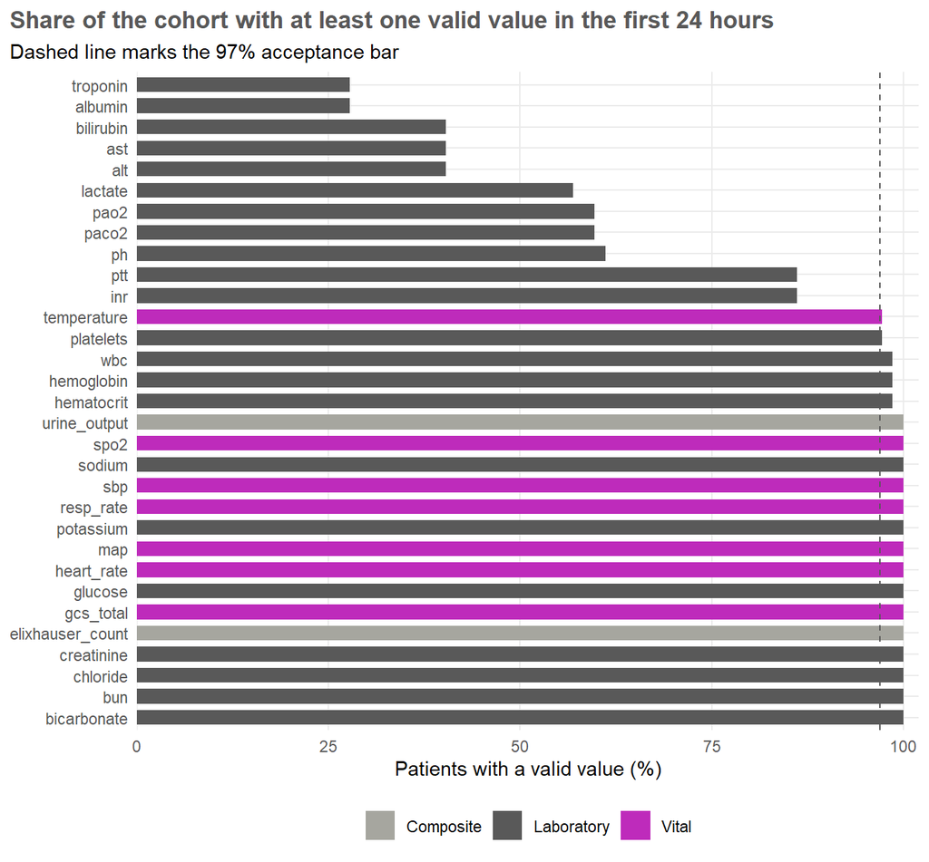

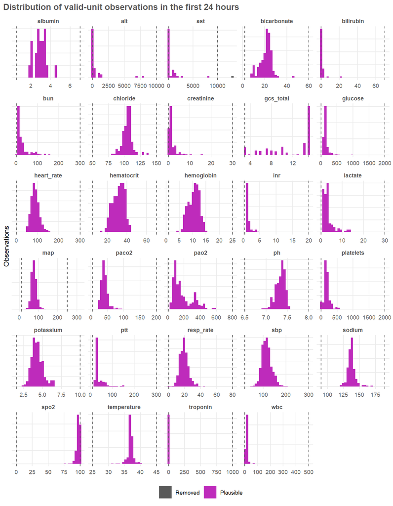

# 5 Stage C: data-quality assessment by domain

## 5.1 Conformance, relational integrity, temporal integrity and uniqueness

Rule-based checks on the raw core tables

Pass = 0 failures; Minor = under 3%; Issue = 3% or more

| Domain | Check | Records checked | Failures | Failure (%) | Status |
| --- | --- | --- | --- | --- | --- |
| Relational | Admissions linked to a patient | 275 | 0 | 0.0 | Pass |
| Relational | ICU stays linked to an admission | 140 | 0 | 0.0 | Pass |
| Relational | ICU stays linked to a patient | 140 | 0 | 0.0 | Pass |
| Relational | ICU-stay patient matches its admission's patient | 140 | 0 | 0.0 | Pass |
| Relational | ICU stays traceable to a transfers row (stay_id = a transfer_id) | 140 | 0 | 0.0 | Pass |
| Uniqueness | Duplicate patient keys | 100 | 0 | 0.0 | Pass |
| Uniqueness | Duplicate admission keys | 275 | 0 | 0.0 | Pass |
| Uniqueness | Duplicate ICU stay keys | 140 | 0 | 0.0 | Pass |
| Uniqueness | Index ICU stays per patient > 1 in analytical cohort | 72 | 0 | 0.0 | Pass |
| Temporal | ICU outtime later than intime | 140 | 0 | 0.0 | Pass |
| Temporal | ICU LOS (days) agrees with outtime - intime (tolerance 0.01 d) | 140 | <10 | 2.9 | Minor |
| Temporal | Hospital discharge later than admission | 275 | 0 | 0.0 | Pass |
| Temporal | ICU stay starts inside the admission interval | 140 | <10 | 1.4 | Minor |
| Temporal | ICU stay ends inside the admission interval | 140 | 22 | 15.7 | Issue |
| Conformance | anchor_age within 18-91 (cap at 91 for >89) | 100 | 0 | 0.0 | Pass |
| Conformance | Age at ICU admission derivable and 18-120 (index cohort) | 72 | 0 | 0.0 | Pass |
| Conformance | Age at admission derivable and 18-120 (all admissions) | 275 | 0 | 0.0 | Pass |
| Conformance | Admission year within 10 years of anchor_year (date-shift coherence) | 275 | 0 | 0.0 | Pass |
| Conformance | hospital_expire_flag in {0, 1} | 275 | 0 | 0.0 | Pass |
| Conformance | Gender in {F, M} | 100 | 0 | 0.0 | Pass |
| Conformance | Mortality flag = 1 has a deathtime (index admission) | 4 | 0 | 0.0 | Pass |
| Conformance | Mortality flag = 0 has no deathtime (index admission) | 68 | 0 | 0.0 | Pass |
| Conformance | Mortality flag agrees with discharge_location = DIED | 72 | 0 | 0.0 | Pass |
| Conformance | Date of death (dod) falls in the index admission when flag = 1 | 4 | 0 | 0.0 | Pass |
| Conformance | Survivors without a date of death inside the index admission | 68 | 0 | 0.0 | Pass |
| Consistency | Race recorded identically across a patient's admissions (multi-admission patients) | 48 | <10 | 8.3 | Issue |

- **Keys, linkage and uniqueness are clean**: every admission links to a patient, every ICU stay to an admission and to a transfer row, and no key is duplicated. Each analytical patient contributes exactly one ICU stay.
- **Mortality is defined consistently at the admission level** (protocol question 5): the flag, `deathtime`, discharge location and date of death all agree for the index admissions.
- **ICU stay end times exceed hospital discharge for 22 of 140 ICU stays** (median overshoot 2.1 hours, maximum 27 hours). The stay and the admission are produced by different systems (`icustays` is derived from transfers), so the two clocks disagree. This does not move the first-24-hour window but it is a relational-timing defect worth reporting to the data owner.
- **`los` does not always equal outtime minus intime** for a few stays, so the protocol’s four-hour rule is evaluated here from the timestamps, not from the `los` column.
- **Race is recorded inconsistently for a small number of patients** across their own admissions, evidence that race is an administrative field captured at each registration rather than a validated attribute.

## 5.2 Temporal integrity of the first-24-hour window

The protocol states the 24-hour restriction is an important fitness-for-purpose rule and “should be explicitly validated”.

Events relative to the index ICU stay

Laboratory events are counted within the index admission; ICU events are those linked to the index stay_id

| Concept | Events in cohort | Before ICU admission | In window | After window | In window (%) | Duplicate events | Charted before stay start |
| --- | --- | --- | --- | --- | --- | --- | --- |
| gcs_total | 5,481 | 15 | 1,670 | 3,796 | 30.5 | 0 | 44 |
| heart_rate | 6,839 | 25 | 2,009 | 4,805 | 29.4 | 0 | 69 |
| map | 6,838 | 18 | 2,085 | 4,735 | 30.5 | <10 | 54 |
| resp_rate | 7,659 | 38 | 2,192 | 5,429 | 28.6 | <10 | 88 |
| sbp | 6,832 | 19 | 2,080 | 4,733 | 30.4 | 0 | 55 |
| spo2 | 6,685 | 25 | 1,962 | 4,698 | 29.3 | <10 | 65 |
| temperature | 1,937 | <10 | 599 | 1,329 | 30.9 | 0 | 23 |
| albumin | 102 | 27 | 22 | 53 | 21.6 | 0 | 0 |
| alt | 237 | 42 | 44 | 151 | 18.6 | 0 | 0 |
| ast | 238 | 42 | 44 | 152 | 18.5 | 0 | 0 |
| bicarbonate | 830 | 81 | 161 | 588 | 19.4 | 0 | 0 |
| bilirubin | 238 | 41 | 47 | 150 | 19.7 | 0 | 0 |
| bun | 838 | 85 | 161 | 592 | 19.2 | 0 | 0 |
| chloride | 936 | 108 | 197 | 631 | 21.0 | 0 | 0 |
| creatinine | 842 | 86 | 161 | 595 | 19.1 | 0 | 0 |
| glucose | 977 | 105 | 247 | 625 | 25.3 | 0 | 0 |
| hematocrit | 932 | 113 | 245 | 574 | 26.3 | 0 | 0 |
| hemoglobin | 856 | 106 | 213 | 537 | 24.9 | 0 | 0 |
| inr | 478 | 55 | 132 | 291 | 27.6 | 0 | 0 |
| lactate | 304 | 29 | 133 | 142 | 43.8 | 0 | 0 |
| paco2 | 470 | 43 | 204 | 223 | 43.4 | 0 | 0 |
| pao2 | 470 | 43 | 204 | 223 | 43.4 | 0 | 0 |
| ph | 516 | 43 | 217 | 256 | 42.1 | 0 | 0 |
| platelets | 779 | 78 | 173 | 528 | 22.2 | 0 | 0 |
| potassium | 1,035 | 113 | 269 | 653 | 26.0 | 0 | 0 |
| ptt | 497 | 87 | 137 | 273 | 27.6 | 0 | 0 |
| sodium | 949 | 107 | 209 | 633 | 22.0 | 0 | 0 |
| troponin | 139 | 17 | 81 | 41 | 58.3 | 0 | <10 |
| wbc | 767 | 77 | 168 | 522 | 21.9 | 0 | 0 |
| urine_output | 3,941 | <10 | 1,074 | 2,864 | 27.3 | <10 | 14 |

Events before ICU admission or after the window are excluded from predictor derivation, as the protocol requires. 'Charted before stay start' are stay-linked ICU events dated before the stay's intime.

- **Only a minority of events fall in the window** (roughly 27 to 31% for ICU chart items), because most of the stay lies beyond 24 hours. The window filter is therefore doing real work: omitting it would let later, outcome-correlated measurements leak into predictors.
- **Stay-linked ICU events dated before ICU admission exist** (tens of events per vital sign), a temporal-integrity defect. They are excluded by the window filter but show that `stay_id` linkage is not a sufficient proxy for time.
- **Laboratory values from the 24 hours before ICU admission** exist for several patients who have no in-window value (see the inventory data), so the strict window forfeits some pre-ICU evidence. Whether that is desirable is a protocol choice, not a data defect.

Window coverage

Stays shorter than 24 h only offer a truncated observation window

| ICU stays in cohort | ICU LOS < 24 h | Share (%) | Median ICU LOS (h) | Median window available (h) |
| --- | --- | --- | --- | --- |
| 72 | <10 | 11.1 | 49.2 | 24 |

## 5.3 Units, source codes and urine output

Concepts fed by more than one source code (protocol question 7)

Unit strings are consistent within each concept except temperature (Celsius versus Fahrenheit)

| Concept | Source codes (item ID, unit): share of valid observations |
| --- | --- |
| chloride | 50806 [mEq/L] 12.6%; 50902 [mEq/L] 87.4% |
| glucose | 50809 [mg/dL] 40.2%; 50931 [mg/dL] 59.8% |
| hematocrit | 50810 [%] 18.5%; 51221 [%] 81.5% |
| hemoglobin | 50811 [g/dL] 21.3%; 51222 [g/dL] 78.7% |
| map | 220052 [mmHg] 48.6%; 220181 [mmHg] 51.4% |
| potassium | 50822 [mEq/L] 36.8%; 50971 [mEq/L] 63.2% |
| resp_rate | 220210 [insp/min] 91.8%; 224690 [insp/min] 8.2% |
| sbp | 220050 [mmHg] 48.7%; 220179 [mmHg] 51.3% |
| sodium | 50824 [mEq/L] 18.1%; 50983 [mEq/L] 81.9% |
| temperature | 223761 [°F] 72.6%; 223762 [°C] 27.4% |
| troponin | 51003 [ng/mL] 38.5%; 227429 [ng/mL] 61.5% |
| urine_output | 226559 [ml] 92%; 226560 [ml] 8% |

Urine output (protocol 10.1)

Ten urine output items; adequate capture assumed at 50% of hours (analyst parameter)

| Check | Result |
| --- | --- |
| Stays with at least one urine-output record in the window | 72 of 72 |
| Median share of available hours with a record (%) | 68.8 |
| Stays with records in at least half of the available hours | 50 of 72 (69.4%) |
| Median hours from ICU admission to first record | 1.8 |
| Records with negative value / missing value / non-mL unit | 0 / 0 / 0 |
| Stays whose 24 h total is exactly zero | <10 |
| Median 24 h total (mL) | 1,722 |

Every analytical patient has urine output recorded, with no negative, missing or non-mL values, but about **three in ten** stays have records in fewer than half of the available hours, so a “24-hour total” is a lower bound of unknown tightness for those stays. The exact urine-output derivation is one of the protocol items that must be verified against the authors’ code.

## 5.4 Comorbidity (Elixhauser) reconstruction

Can the Elixhauser count be reconstructed? (protocol question 18)

| Item | Value |
| --- | --- |
| Index admissions with diagnosis codes | 72 of 72 |
| Diagnosis rows | 1,146 |
| ICD-9 / ICD-10 rows | 785 / 361 |
| Rows matched to the TinyEHR dictionary (%) | 100 |
| Rows with a decimal point in the code (%) | 95.6 |
| Elixhauser categories implemented (Quan, ICD-9 and ICD-10) | 31 |

Yes, with three caveats. TinyEHR inserts a decimal after the third character of ICD codes, so codes must be de-punctuated before applying published Elixhauser maps (limitation L7). Both ICD versions occur and need their own map. And `diagnoses_icd` holds **billing codes assigned after discharge**: using them as a predictor at 24 hours uses information that was not available at prediction time, so the Elixhauser predictor carries a latent timing leak that the protocol does not discuss.

# 6 Perfect-record score and error Pareto

Redman perfect-record score

A record is perfect only if no critical data element has an error

| CDE set | CDEs | Records | Perfect records | Perfect (%) | 95% CI (Wilson) | Meets 97% bar |
| --- | --- | --- | --- | --- | --- | --- |
| Index record (5 CDEs) | 5 | 72 | 61 | 84.7 | 74.7 to 91.2 | No |
| Index + 7 vital signs (12 CDEs) | 12 | 72 | 59 | 81.9 | 71.5 to 89.1 | No |
| Full analytical set (15 CDEs) | 15 | 72 | 59 | 81.9 | 71.5 to 89.1 | No |
| Full set excluding race (14 CDEs) | 14 | 72 | 69 | 95.8 | 88.5 to 98.6 | No |

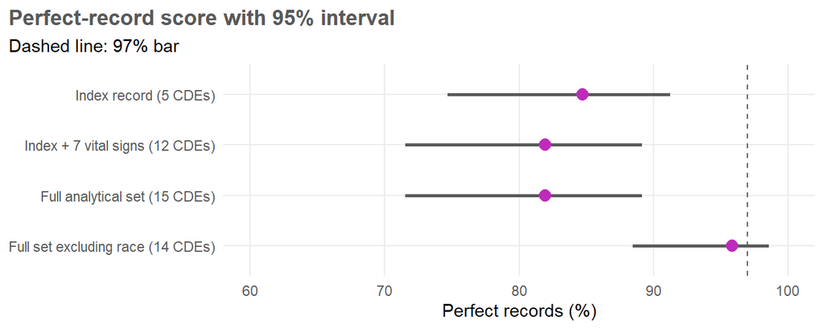

Error Pareto

Only three error types occur; counts of 1 to 9 suppressed

| Critical data element | Error type | Errors | Share of all errors (%) | Cumulative (%) |
| --- | --- | --- | --- | --- |
| race | Missing / unknown | 10 | 76.9 | 76.9 |
| temperature | Missing (no observation in window) | <10 | 15.4 | 92.3 |
| icu_timestamps | Inconsistent or invalid | <10 | 7.7 | 100.0 |

**One defect carries three quarters of all errors: race recorded as missing or unknown** (UNKNOWN, UNABLE TO OBTAIN, PATIENT DECLINED), affecting about one patient in seven. The remaining errors are a missing temperature and one inconsistent ICU timestamp. Without race the perfect-record score is 95.8%, still just under the bar. The sample is too small for the interval to exclude 97%.

This is not a random error: race is an administrative registration field, and the MDLA study asks whether missing data encode demographic information. In a dataset where race itself is largely unknown for one patient in seven, the protocol’s race analyses start from a compromised label. This is the *Proxy Trap* failure pattern: a field recorded for another purpose is used as a clinical or demographic truth.

## 6.1 Variation across units

Perfect-record score by harmonised ICU type

Units with fewer than 10 patients are suppressed

| ICU type | Patients | Perfect (%) | 95% CI |
| --- | --- | --- | --- |
| CCU | <10 | - | suppressed (n < 10) |
| MICU | 13 | 69.2 | 42.4 to 87.3 |
| NICU | <10 | - | suppressed (n < 10) |
| Other | 27 | 85.2 | 67.5 to 94.1 |
| SICU | 17 | 82.4 | 59 to 93.8 |
| TSICU | <10 | - | suppressed (n < 10) |

The three reportable units overlap widely; with 13 to 27 patients each no unit can be declared out of control. **Stability over time cannot be assessed**: TinyEHR shifts every date per patient, so calendar trends in volume, missingness or drift (Tate’s *Silent Drift*) are not identifiable and are reported as *unmeasured*, not as stable.

# 7 Stage D: missingness audit

## 7.1 Indicator bookkeeping

Protocol indicators versus measurable concepts

| Item | Count |
| --- | --- |
| Protocol: candidate features (20 vital + 22 lab + 2 composite) | 44 |
| Protocol: indicators incl. troponin | 44 |
| Distinct measurable concepts here (7 vitals + 22 labs + 2 composites) | 31 |
| Vital-sign domains behind the 20 vital features | 7 |
| Concepts with constant missingness in this cohort (untestable) | 15 |
| Concepts with variable missingness (testable) | 16 |

The protocol builds 44 missingness indicators from 44 features, but its 20 vital-sign features come from only **7 vital-sign domains**: the minimum, maximum and mean of one domain are observed or missing together, so those indicators are perfectly collinear. The number of *distinct* missingness signals is 31, and in this cohort only 16 of them vary at all. The “44 indicators” figure overstates the information content (*Metric Mirage*).

## 7.2 Missingness by concept and subgroup

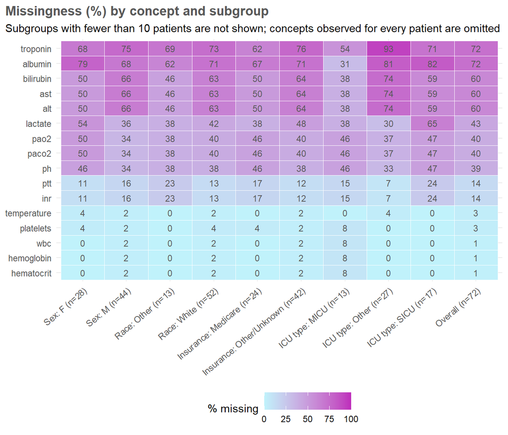

15 of 31 concepts have constant missingness (all observed: 15; all missing: 0) and are untestable as MDLA indicators; this includes every vital sign except temperature and the routine chemistry panel. Subgroup axes are thin: 2 sex levels, 2 race levels, 2 insurance levels and 3 ICU types have at least 10 patients.

Among the subgroups that can be shown, the largest gap in missingness for any one concept is **52 percentage points across ICU types** (albumin), 17 points by sex (lactate), 14 points by insurance (alt) and 17 points by race (alt). The care setting (ICU type) therefore shapes which tests are measured more than any demographic axis in this cohort, which is the MDLA concern in miniature: missingness patterns are informative, but with 13 to 52 patients per shown group the gaps are descriptive and carry no inferential weight.

## 7.3 Correlation among missingness indicators

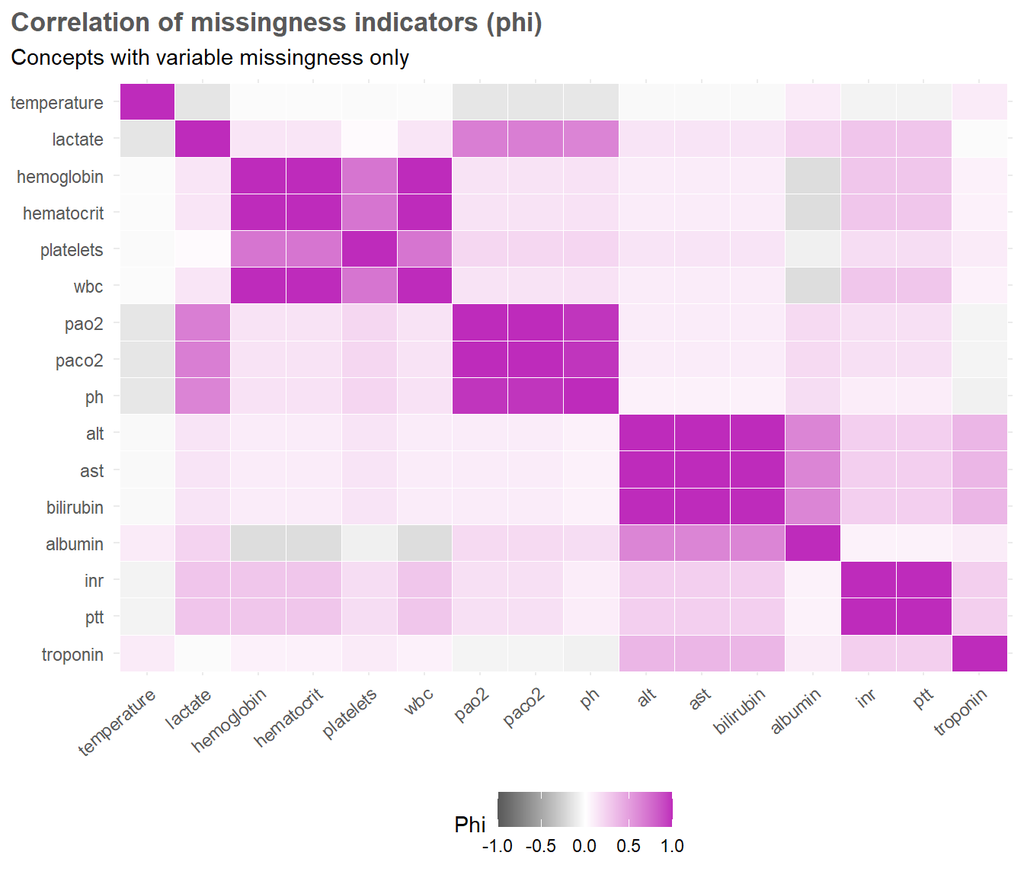

Several indicators are identical (phi = 1): hemoglobin, hematocrit and white cell count; PaO2 and PaCO2 (pH is almost identical); ALT, AST and bilirubin; INR and PTT. Lactate follows the blood gases only partly (phi about 0.7). Co-missingness reflects ordering *panels*, so the indicators are not independent features: a model given all of them would see a few clinical order sets, not 44 separate signals.

## 7.4 Feasibility of the protocol’s association tests

Chi-square testing of missingness against race

Feasibility only; no p-values are reported

| Item | Value |
| --- | --- |
| Missingness indicators with variable missingness (testable) | 16 |
| Protocol association tests (Bonferroni divisor) | 43 |
| Race groups present / with at least 10 patients | 4 / 2 |
| Median share of chi-square cells with expected count < 5 (%) | 62.5 |
| Indicators where more than 20% of cells have expected count < 5 | 16 of 16 |

Every testable indicator violates the usual chi-square validity rule (expected cell count of at least 5 in 80% of cells). **No inferential claim about missingness and race is made**, in line with protocol section 22 Stage D.